# Bagging y Random Forest para clasificación

[Javier Cara](https://javiercara.github.io/)

## Descripción

El archivo “winequality.csv” contiene datos que relacionan la calidad de 4898 y 1599 diferentes tipos de vino blanco y rojo (respectivamente), con un total de 11 parámetros químicos medidos en dichos vinos. El archivo “winequality-names.txt” contiene más información de los datos. Se pide:

1. Comentar si hay diferencias en las variables medidas según sea el vino blanco o rojo.
2. Dividir los datos en dos partes iguales: una parte para entrenar el modelo y otra parte para comprobar la calidad de la predicción (utilizar como semilla en numero 123).
3. Calcular el error cometido cuando se analiza la calidad del vino (variable quality) en función de las otras variables utilizando:
   1. Un sólo árbol.
   2. Bagging.
   3. Random forest.

## a) Solución

```r
datos = read.csv("winequality.csv",header=T,sep=";")
# comprobamos que el tipo de vino (white-red) es de tipo factor
is.factor(datos$tipo)
```

```
## [1] TRUE
```

Como ejemplo, vamos a ver si hay diferencias en el contenido en alcohol según sea el vino rojo o blanco:

```r
library(tree)
t1 = tree(alcohol ~ tipo, data = datos)
print(t1)
```

```
## node), split, n, deviance, yval
##       * denotes terminal node
##
## 1) root 6497 9241 10.49 *
```

El árbol sólo tiene un nodo, no se ha conseguido dividir los datos en función del tipo de vino. Luego los vinos rojos y blancos no tienen diferente contenido en alcohol.

## b) Solución

```r
set.seed(123)
ndat = nrow(datos)
train = sample(1:ndat,ndat/2) # la mitad de los datos para entranamiento
datos_t = datos[train,] # trainning set
datos_v = datos[-train,] # validation set
```

## c) Solución

### c.i) solución

```r
t2 = tree(quality ~ ., data = datos_t)
```

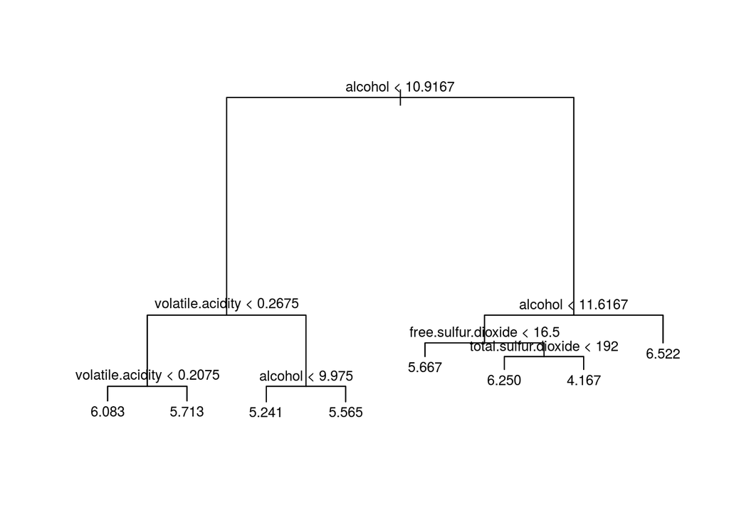

```r
# dibujamos el arbol
plot(t2)
text(t2,pretty=0,cex=0.8)
```

Como vemos, no estamos haciendo bien el ejercicio ya que estamos prediciendo puntuaciones como 6.083, 5.713, …, cuando deberían ser números enteros entre 1 y 10. En realidad, *quality* es una variable qualitativa de tipo ordinal. Completamos nuestros datos con la variable *qualityF*, que es de tipo factor.

```r
datos = data.frame(datos, qualityF = as.factor(datos$quality))
datos_t = datos[train,] # trainning set
datos_v = datos[-train,] # validation set
```

Volvemos a estimar el árbol, pero esta vez consideramos *qualityF* como variable respuesta

```r
t3 = tree(qualityF ~ .-quality, data = datos_t) # quitamos quality, no puede ser variable explicativa ya que tiene la misma informacion que qualityF
```

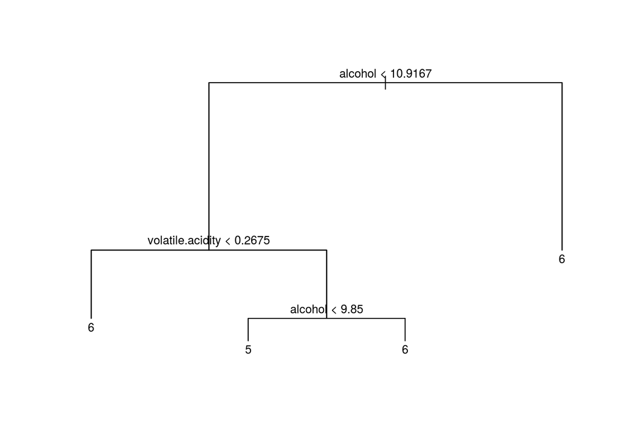

```r
# dibujamos el arbol
plot(t3)
text(t3,pretty=0,cex=0.8)
```

```r
summary(t3)
```

```
##
## Classification tree:
## tree(formula = qualityF ~ . - quality, data = datos_t)
## Variables actually used in tree construction:
## [1] "alcohol"          "volatile.acidity"
## Number of terminal nodes:  4
## Residual mean deviance:  2.246 = 7285 / 3244
## Misclassification error rate: 0.4858 = 1578 / 3248
```

Ahora la predicción tiene mejor pinta, ya que predice valores enteros. Sin embargo, la predicción es muy pobre, ya que solo predice calidades 5 y 6. Vamos a ver el error que hemos cometido:

```r
# error del modelo
yt_p = predict(t3,newdata = datos_t, type="class")
yt = datos_t$qualityF
# creamos una tabla
mt = table(yt_p, yt)
mt
```

```
##     yt
## yt_p    3    4    5    6    7    8    9
##    3    0    0    0    0    0    0    0
##    4    0    0    0    0    0    0    0
##    5    4   45  528  226    9    0    0
##    6   15   65  550 1142  573   89    2
##    7    0    0    0    0    0    0    0
##    8    0    0    0    0    0    0    0
##    9    0    0    0    0    0    0    0
```

Hay 528 vinos de calidad 5 y 1142 vinos de calidad 6 corréctamente predichos. El resto, (3248 - 528 - 1142) = 1578 , están mal predichos. La proporción de fallos (error cometido) es 1578/3248 = 0.4858374.

```r
# error cometido
eti = (nrow(datos_t) - sum(diag(mt)))/nrow(datos_t)
eti
```

```
## [1] 0.4858374
```

Vamos a ver el error cometido con los datos de validación:

```r
# error de prediccion
yv_p = predict(t3,newdata = datos_v, type="class")
yv = datos_v$qualityF
# creamos una tabla
mv = table(yv_p, yv)
mv
```

```
##     yv
## yv_p    3    4    5    6    7    8    9
##    3    0    0    0    0    0    0    0
##    4    0    0    0    0    0    0    0
##    5    3   34  484  215    8    1    0
##    6    8   72  576 1253  489  103    3
##    7    0    0    0    0    0    0    0
##    8    0    0    0    0    0    0    0
##    9    0    0    0    0    0    0    0
```

```r
# Error cometido
evi = (nrow(datos_v) - sum(diag(mv)))/nrow(datos_v)
evi
```

```
## [1] 0.465374
```

### c.ii) solución

```r
library(randomForest)
bag1 = randomForest(qualityF ~ . - quality, data = datos_t, mtry=12, ntree = 500)
```

```r
# error del modelo
yt_p = predict(bag1,newdata = datos_t, type="class")
mt = table(yt_p, yt)
mt
```

```
##     yt
## yt_p    3    4    5    6    7    8    9
##    3   19    0    0    0    0    0    0
##    4    0  110    0    0    0    0    0
##    5    0    0 1078    0    0    0    0
##    6    0    0    0 1368    0    0    0
##    7    0    0    0    0  582    0    0
##    8    0    0    0    0    0   89    0
##    9    0    0    0    0    0    0    2
```

```r
# error cometido
etii = (nrow(datos_t) - sum(diag(mt)))/nrow(datos_t)
etii
```

```
## [1] 0
```

```r
# error de prediccion
yv_p = predict(bag1,newdata = datos_v, type="class")
yv = datos_v$qualityF
# creamos una tabla
mv = table(yv_p, yv)
mv
```

```
##     yv
## yv_p    3    4    5    6    7    8    9
##    3    0    0    0    0    0    0    0
##    4    1   12    2    0    0    0    0
##    5    4   60  722  264   14    2    0
##    6    6   31  320 1077  209   46    1
##    7    0    3   15  126  270   27    2
##    8    0    0    1    1    4   29    0
##    9    0    0    0    0    0    0    0
```

```r
# error cometido
evii = (nrow(datos_v) - sum(diag(mv)))/nrow(datos_v)
evii
```

```
## [1] 0.3505694
```

### c.iii) solución

```r
rf1 = randomForest(qualityF ~ . - quality, data = datos_t, mtry=5, ntree = 500)
```

```r
# error del modelo
yt_p = predict(rf1,newdata = datos_t, type="class")
mt = table(yt_p, yt)
mt
```

```
##     yt
## yt_p    3    4    5    6    7    8    9
##    3   19    0    0    0    0    0    0
##    4    0  110    0    0    0    0    0
##    5    0    0 1078    0    0    0    0
##    6    0    0    0 1368    0    0    0
##    7    0    0    0    0  582    0    0
##    8    0    0    0    0    0   89    0
##    9    0    0    0    0    0    0    2
```

```r
# error cometido
etiii = (nrow(datos_t) - sum(diag(mt)))/nrow(datos_t)
etiii
```

```
## [1] 0
```

```r
# error de prediccion
yv_p = predict(rf1,newdata = datos_v, type="class")
yv = datos_v$qualityF
# creamos una tabla
mv = table(yv_p, yv)
mv
```

```
##     yv
## yv_p    3    4    5    6    7    8    9
##    3    0    0    0    0    0    0    0
##    4    1   10    0    0    0    0    0
##    5    4   56  713  256    8    1    0
##    6    6   38  338 1092  214   43    1
##    7    0    2    8  120  273   32    2
##    8    0    0    1    0    2   28    0
##    9    0    0    0    0    0    0    0
```

```r
# error cometido
eviii = (nrow(datos_v) - sum(diag(mv)))/nrow(datos_v)
eviii
```

```
## [1] 0.3487227
```

### Conclusiones

```r
res = matrix(c(eti,evi,etii,evii,etiii,eviii), byrow = T, ncol = 2)
colnames(res) = c("Training", "Validation")
rownames(res) = c("Tree", "Bagging", "RandomForest")
```

Los errores cometidos con los distintos métodos son:

```r
print(round(res*100,digits = 2))
```

```
##              Training Validation
## Tree            48.58      46.54
## Bagging          0.00      35.06
## RandomForest     0.00      34.87
```